# R markdown_MarieLaureJOVIAL_EnronProject

2024-11-07

## Loading data and library

```r
library(ggplot2)
library(dplyr)
library(bslib)
library(lubridate)
library(ggiraph)
library(stringr)
library(tidyr)
load('C:\\Users\\MarieLaureJovial\\Downloads\\R BIG DATA PROCESSING\\Enron.Rdata')
```

## Quick pre exploration of the data

```
## [1] " Number of messages:  252759"
```

```
## [1] " Number of person in employeelist:  149"
```

```
## [1] " Number of recipients:  2064442"
```

Based on the second question in the exam instruction, we have a look at the different existent status and their distribution

```r
table(employeelist$status)
```

```
##
##               CEO          Director          Employee   In House Lawyer
##                 4                14                41                 1
##           Manager Managing Director               N/A         President
##                14                 3                31                 4
##            Trader    Vice President
##                13                23
```

A total of 252759 messages were sent to 2064442 recipients.

We observe that some messages was sent with recipient directly or in a hidden manner.

```r
recipientinfo%>% group_by(rtype) %>% summarise(ComType = n())
```

```
## # A tibble: 3 × 2
##   rtype ComType
##   <fct>   <int>
## 1 BCC    253713
## 2 CC     253735
## 3 TO    1556994
```

Recipients mostly received messages that were meant for them. An interesting point might be analyzing if the number of hidden recipient increased during tense period for the company.

# OBJECTIVE 1: ANALYZE THE EMAIL SENT BY USERS (USER FOCUSED)

Cleaning and making some transformation to the data

```r
#Replacing the null status in employeelist by N/A
employeelist$status[is.na(employeelist$status)] <- "N/A"

#Making sure that the date column is explotable for future visuals
message$date <- as.Date(trimws(ymd(message$date)))

#Adding a fullName column to employeelist
employeelistFN <- mutate(employeelist, fullName = paste(employeelist$firstName, employeelist$lastName))
```

### RELEVANT QUESTION TO OBJECTIVE 1

**-How many messages were sent? how and by who ?**  
**-Is there a group who is more active than another ?**

**Transforming employeelist table :**  
To answer these questions we must join the employeelistFN table with the message table.  
Given each employee can have up to 4 email, the join must be performed for each email.

```r
#Join of employeelist table and message table on Email_id
EmployeelistFN1 <-
employeelistFN %>%
select(eid,Email_id,status,fullName)%>%
inner_join(message, by=c("Email_id"="sender"))
dim(EmployeelistFN1)
```

```
## [1] 104766      8
```

```r
#Join of employeelist table and message table on Email2
EmployeelistFN2 <-
employeelistFN %>%
filter(!is.na(Email2) & Email2 !="")%>%
select(eid,Email2,status,fullName)%>%
inner_join(message, by=c("Email2"="sender"))
dim(EmployeelistFN2)
```

```
## [1] 0 8
```

```r
#Join of employeelist table and message table  on Email3
EmployeelistFN3 <-
employeelistFN %>%
filter(!is.na(Email3) & Email3 !="")%>%
select(eid,Email3,status,fullName)%>%
inner_join(message, by=c("Email3"="sender"))
dim(EmployeelistFN3)
```

```
## [1] 1170    8
```

```r
#Join of employeelist table and message table  on Email4
EmployeelistFN4 <-
employeelistFN %>%
filter(!is.na(EMail4) & EMail4 !="")%>%
select(eid,EMail4,status,fullName)%>%
inner_join(message, by=c("EMail4"="sender"))
dim(EmployeelistFN4)
```

```
## [1] 0 8
```

```r
#Appending all 4 data
EmployeeMessageSent <- bind_rows(EmployeelistFN1, EmployeelistFN2, EmployeelistFN3, EmployeelistFN4)
```

**COMMENT**:  
104766 emails were sent with Email_id and 1170 emails were sent with Email_3 which makes a **total of 105936 emails**.  
This also means that only **41.9% of the 252759 messages were sent by users**.  
Note that emails were only emitted from Email_id and Email3.

### INVESTIGATING THE NUMBER OF EMAIL SENT BY USER

#### Who are the most active senders ?

```r
#Calculating the amount of message sent by each user
MsgByEid <- EmployeeMessageSent %>% group_by(eid, fullName, status) %>% summarise(TotalMessageSent = n()) %>% arrange(desc(TotalMessageSent))
MsgByEid
```

```
## # A tibble: 149 × 4
## # Groups:   eid, fullName [149]
##      eid fullName          status         TotalMessageSent
##    <dbl> <chr>             <fct>                     <int>
##  1    73 Jeff Dasovich     Employee                   6273
##  2   109 Vince Kaminski    Manager                    5838
##  3    52 Kay Mann          Employee                   5100
##  4    67 Sara Shackleton   N/A                        4797
##  5    48 Tana Jones        N/A                        4437
##  6   114 Chris Germany     Employee                   3686
##  7    61 Matthew Lenhart   Employee                   2784
##  8    76 Debra Perlingiere Employee                   2549
##  9    51 Steven Kean       Vice President             2278
## 10    75 Gerald Nemec      N/A                        2275
## # ℹ 139 more rows
```

```r
#Calculating the amount of message sent by an average user
MeanofMsgByEid <- round(mean(MsgByEid$TotalMessageSent),0)
print(paste("In average a user sends ", MeanofMsgByEid, "messages"))
```

```
## [1] "In average a user sends  711 messages"
```

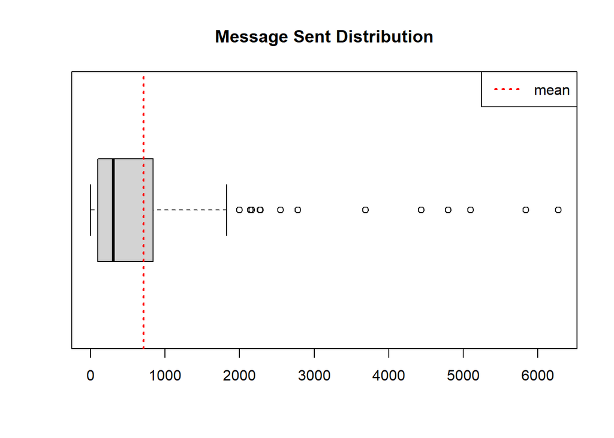

```r
#Visualising the distibution of message sent by user
boxplot(MsgByEid$TotalMessageSent, horizontal = TRUE)
title("Message Sent Distribution")
abline(v=MeanofMsgByEid, lty=3, lwd=2, col="red")
legend("topright", legend = c('mean'), lty = 3, lwd = 2, col = 'red')
```

**COMMENT**:  
The most active sender is the Employee Jeff Dasovich with 6273 emails sent.  
The less active sender is the N/A Steven Merris with 1 email sent.  
In average a user sends 711 emails.

Howerver, 50% of the users have sent between 101 and 843 messages (Q1-Q3).  
The average of message sent being so close to the 3rd quantile and so far from the average shows that some user are sending an extreme amount of messages which is leading to such a difference between the median and the mean.

```r
#Defining if the top active emailers where still there during tense period of the company

library(lubridate)
EmployeeMessageSent$date <- ymd(EmployeeMessageSent$date)
LastSent <- EmployeeMessageSent %>% select (fullName,date) %>% group_by(fullName) %>% mutate (LatestEmail= max(date))  %>% distinct(fullName, LatestEmail, .keep_all = FALSE)

TopSender_LatestEmailSent<-merge(MsgByEid,LastSent) %>% arrange(desc(TotalMessageSent))
head(TopSender_LatestEmailSent,15)
```

```
##             fullName eid         status TotalMessageSent LatestEmail
## 1      Jeff Dasovich  73       Employee             6273  2002-09-22
## 2     Vince Kaminski 109        Manager             5838  2002-01-30
## 3           Kay Mann  52       Employee             5100  2002-05-28
## 4    Sara Shackleton  67            N/A             4797  2002-03-25
## 5         Tana Jones  48            N/A             4437  2002-02-08
## 6      Chris Germany 114       Employee             3686  2002-06-25
## 7    Matthew Lenhart  61       Employee             2784  2002-02-05
## 8  Debra Perlingiere  76       Employee             2549  2002-03-25
## 9        Steven Kean  51 Vice President             2278  2001-12-27
## 10      Gerald Nemec  75            N/A             2275  2002-02-21
## 11     James Steffes  23 Vice President             2161  2002-02-03
## 12       Mark Taylor   6       Employee             2146  2001-11-27
## 13   Richard Sanders  14 Vice President             1998  2002-02-19
## 14       Carol Clair 147 Vice President             1827  2001-06-11
## 15       Susan Scott  49            N/A             1823  2002-05-22
```

### INVESTIGATING THE POSSIBLE INFLUENCE OF STATUS ON EMAILS SENT.

### Overview by status

```r
#Using the table function to summarize the message sent by status
table(EmployeeMessageSent$status)
```

```
##
##               CEO          Director          Employee   In House Lawyer
##              1388              3005             37267               763
##           Manager Managing Director               N/A         President
##             13447              1176             24313              3619
##            Trader    Vice President
##              3800             17158
```

#### Which groups are the most active ?

```r
#Defining the quantity of email sent by status in absolute number and in percentage.


MsgByStatus <- EmployeeMessageSent %>% group_by(status) %>% summarise(TotalSent = n()) %>%arrange(desc(TotalSent))%>% mutate(TotalSentPercentage= round(TotalSent/sum(TotalSent)*100))
MsgByStatus
```

```
## # A tibble: 10 × 3
##    status            TotalSent TotalSentPercentage
##    <fct>                 <int>               <dbl>
##  1 Employee              37267                  35
##  2 N/A                   24313                  23
##  3 Vice President        17158                  16
##  4 Manager               13447                  13
##  5 Trader                 3800                   4
##  6 President              3619                   3
##  7 Director               3005                   3
##  8 CEO                    1388                   1
##  9 Managing Director      1176                   1
## 10 In House Lawyer         763                   1
```

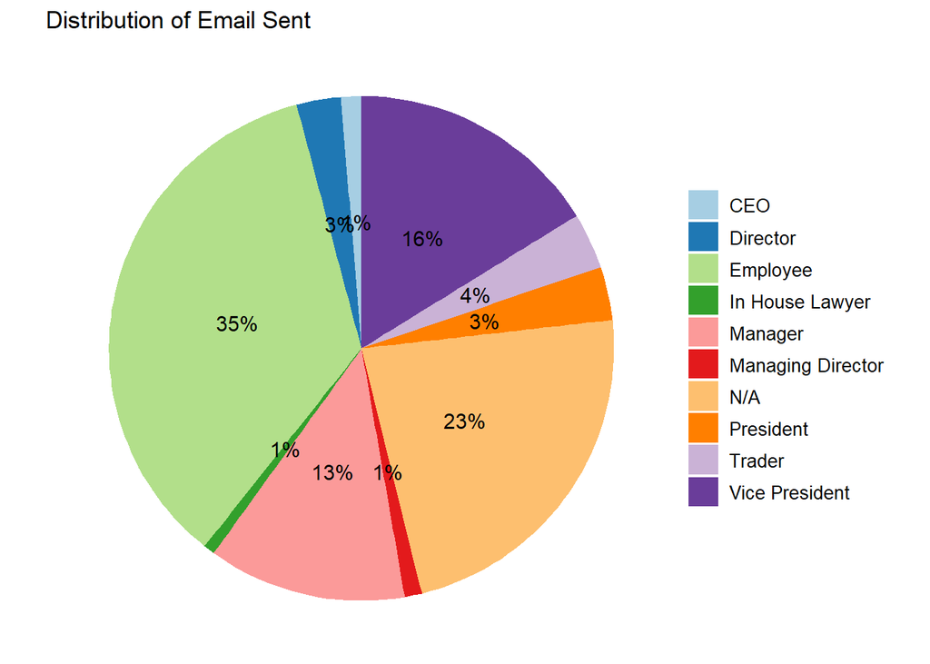

```r
#Representing  the repartition in % in a pie chart

ggplot(data = MsgByStatus, aes(x = '', y = TotalSent, fill = status)) +
  geom_bar(stat = 'identity', width = 1) +  # Create bars to form a pie
  geom_text(aes(label = paste0(TotalSentPercentage, '%')),
            position = position_stack(vjust = 0.5), color = 'black', size = 4) +  # Add percentage labels
  coord_polar(theta = 'y') +  # Turn the bar chart into a pie chart
  theme_void() +  # Remove background
  scale_fill_brewer(palette = "Paired") +  # Choose a color palette for better readability
  theme(legend.title = element_blank(),  # Remove legend title for clarity
        legend.text = element_text(size = 10))+  # Adjust legend text size
  ggtitle("Distribution of Email Sent ")
```

**COMMENT:** As Employees, N/A’s and Vice President user status are the most common it is with little surprise that, 35% messages were sent by employees, 23% of messages were sent by N/A’s (23%) followed by 16% sent by Vice Presidents. Indeed out of the 149 users, 41 are Employees, 31 are N/A’s and 23 are Vice President (see exploration part)

However we can further investigate if this is the only explanation

### Further exploration of status impact with basic statistic concepts.

```r
MsgBySender <- EmployeeMessageSent %>% group_by(eid, fullName, status)%>% summarise(TotalSent = n())
MsgBySender_CEO <- select(filter(MsgBySender, status=="CEO"),status,TotalSent)
MsgBySender_Director <- select(filter(MsgBySender, status=="Director"),status,TotalSent)
MsgBySender_Employee <- select(filter(MsgBySender, status=="Employee"),status,TotalSent)
MsgBySender_IHL <- select(filter(MsgBySender, status=="In House Lawyer"),status,TotalSent)
MsgBySender_Manager <- select(filter(MsgBySender, status=="Manager"),status,TotalSent)
MsgBySender_MDirector <- select(filter(MsgBySender, status=="Managing Director"),status,TotalSent)
MsgBySender_NA <- select(filter(MsgBySender, status=="N/A"),status,TotalSent)
MsgBySender_President <- select(filter(MsgBySender, status=="President"),status,TotalSent)
MsgBySender_Trader <- select(filter(MsgBySender, status=="Trader"),status,TotalSent)
MsgBySender_VicePresident <- select(filter(MsgBySender, status=="Vice President"),status,TotalSent)
summary(MsgBySender_CEO)
```

```
##       eid           fullName                       status    TotalSent
##  Min.   : 46.00   Length:4           CEO              :4   Min.   : 30.00
##  1st Qu.: 51.25   Class :character   Director         :0   1st Qu.: 59.25
##  Median : 90.00   Mode  :character   Employee         :0   Median :236.00
##  Mean   : 88.75                      In House Lawyer  :0   Mean   :347.00
##  3rd Qu.:127.50                      Manager          :0   3rd Qu.:523.75
##  Max.   :129.00                      Managing Director:0   Max.   :886.00
##                                      (Other)          :0
```

```r
summary(MsgBySender_Director)
```

```
##       eid           fullName                       status     TotalSent
##  Min.   :  1.00   Length:14          Director         :14   Min.   :  11.00
##  1st Qu.: 22.25   Class :character   CEO              : 0   1st Qu.:  31.25
##  Median : 99.00   Mode  :character   Employee         : 0   Median : 112.00
##  Mean   : 73.79                      In House Lawyer  : 0   Mean   : 214.64
##  3rd Qu.:105.50                      Manager          : 0   3rd Qu.: 205.75
##  Max.   :130.00                      Managing Director: 0   Max.   :1116.00
##                                      (Other)          : 0
```

```r
summary(MsgBySender_Employee)
```

```
##       eid           fullName                       status     TotalSent
##  Min.   :  3.00   Length:41          Employee         :41   Min.   :   2
##  1st Qu.: 25.00   Class :character   CEO              : 0   1st Qu.: 100
##  Median : 64.00   Mode  :character   Director         : 0   Median : 319
##  Mean   : 66.15                      In House Lawyer  : 0   Mean   : 909
##  3rd Qu.:100.00                      Manager          : 0   3rd Qu.:1110
##  Max.   :149.00                      Managing Director: 0   Max.   :6273
##                                      (Other)          : 0
```

```r
summary(MsgBySender_IHL)
```

```
##       eid       fullName                       status    TotalSent
##  Min.   :74   Length:1           In House Lawyer  :1   Min.   :763
##  1st Qu.:74   Class :character   CEO              :0   1st Qu.:763
##  Median :74   Mode  :character   Director         :0   Median :763
##  Mean   :74                      Employee         :0   Mean   :763
##  3rd Qu.:74                      Manager          :0   3rd Qu.:763
##  Max.   :74                      Managing Director:0   Max.   :763
##                                  (Other)          :0
```

```r
summary(MsgBySender_Manager)
```

```
##       eid          fullName                       status     TotalSent
##  Min.   :  4.0   Length:14          Manager          :14   Min.   :  18.0
##  1st Qu.: 28.5   Class :character   CEO              : 0   1st Qu.: 216.2
##  Median : 99.0   Mode  :character   Director         : 0   Median : 556.5
##  Mean   : 74.0                      Employee         : 0   Mean   : 960.5
##  3rd Qu.:115.5                      In House Lawyer  : 0   3rd Qu.: 969.5
##  Max.   :123.0                      Managing Director: 0   Max.   :5838.0
##                                     (Other)          : 0
```

```r
summary(MsgBySender_MDirector)
```

```
##       eid          fullName                       status    TotalSent
##  Min.   : 65.0   Length:3           Managing Director:3   Min.   :   9.0
##  1st Qu.: 87.5   Class :character   CEO              :0   1st Qu.:  28.0
##  Median :110.0   Mode  :character   Director         :0   Median :  47.0
##  Mean   :104.3                      Employee         :0   Mean   : 392.0
##  3rd Qu.:124.0                      In House Lawyer  :0   3rd Qu.: 583.5
##  Max.   :138.0                      Manager          :0   Max.   :1120.0
##                                     (Other)          :0
```

```r
summary(MsgBySender_NA)
```

```
##       eid           fullName                     status     TotalSent
##  Min.   : 11.00   Length:32          N/A            :32   Min.   :   1.0
##  1st Qu.: 49.75   Class :character   CEO            : 0   1st Qu.: 123.5
##  Median : 77.00   Mode  :character   Director       : 0   Median : 307.5
##  Mean   : 80.91                      Employee       : 0   Mean   : 759.8
##  3rd Qu.:107.50                      In House Lawyer: 0   3rd Qu.: 835.5
##  Max.   :150.00                      Manager        : 0   Max.   :4797.0
##                                      (Other)        : 0
```

```r
summary(MsgBySender_President)
```

```
##       eid           fullName                     status    TotalSent
##  Min.   : 36.00   Length:4           President      :4   Min.   : 223.0
##  1st Qu.: 49.50   Class :character   CEO            :0   1st Qu.: 411.2
##  Median : 60.00   Mode  :character   Director       :0   Median : 946.0
##  Mean   : 65.75                      Employee       :0   Mean   : 904.8
##  3rd Qu.: 76.25                      In House Lawyer:0   3rd Qu.:1439.5
##  Max.   :107.00                      Manager        :0   Max.   :1504.0
##                                      (Other)        :0
```

```r
summary(MsgBySender_Trader)
```

```
##       eid           fullName                     status     TotalSent
##  Min.   : 22.00   Length:13          Trader         :13   Min.   :  24.0
##  1st Qu.: 58.00   Class :character   CEO            : 0   1st Qu.:  73.0
##  Median : 91.00   Mode  :character   Director       : 0   Median : 193.0
##  Mean   : 91.77                      Employee       : 0   Mean   : 292.3
##  3rd Qu.:131.00                      In House Lawyer: 0   3rd Qu.: 235.0
##  Max.   :134.00                      Manager        : 0   Max.   :1644.0
##                                      (Other)        : 0
```

```r
summary(MsgBySender_VicePresident)
```

```
##       eid          fullName                     status     TotalSent
##  Min.   : 14.0   Length:23          Vice President :23   Min.   :  87
##  1st Qu.: 37.5   Class :character   CEO            : 0   1st Qu.: 283
##  Median : 68.0   Mode  :character   Director       : 0   Median : 502
##  Mean   : 70.3                      Employee       : 0   Mean   : 746
##  3rd Qu.: 94.0                      In House Lawyer: 0   3rd Qu.: 912
##  Max.   :147.0                      Manager        : 0   Max.   :2278
##                                     (Other)        : 0
```

CEO and Presidents status seems to be the status with the most centered distribution and non excessive outliers ( reasonnable maximum)

For other status, we observe a big dispersion in the data. The means can be way superior to the median ( espcially for Employees, Manahers, Managing Director’ and N/A’s ) explain by the presence of many users in these status being more active ( larger gap between Q3 and max)

```
 We can illustrate this comment using a box plot by status
```

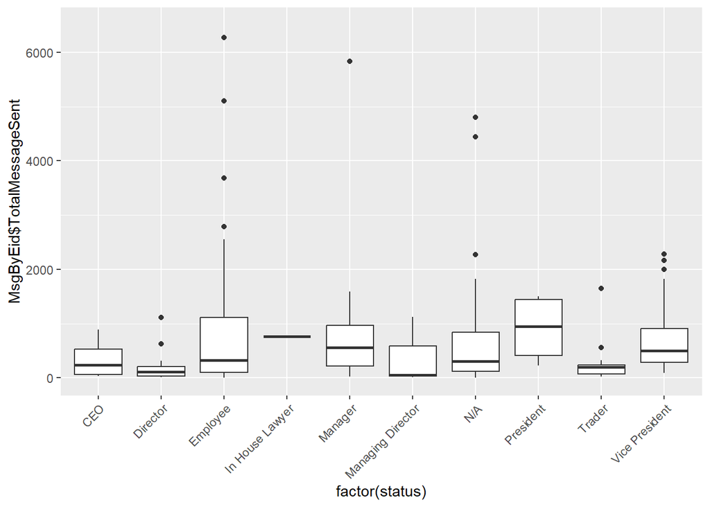

```r
#Visualising previous comment with Boxplot by status
ggplot(data=MsgByEid)+ geom_boxplot(aes(x=factor(status),y=MsgByEid$TotalMessageSent))+
  ylim(0,6500) +
  theme(axis.text.x = element_text(angle = 45, hjust = 1))
```

# OBJECTIVE 2: ANALYZE THE EMAIL RECIPIENTS (USER FOCUSED)

### Overview of the received emails (user AND non-user)

```r
NB_Recipient <- nrow(recipientinfo)
NB_UniqueRecipient <- length(unique(recipientinfo$rvalue))
NB_UniqueMessages <- length(unique(recipientinfo$mid))
print(paste("Number of recipients:", NB_Recipient))
```

```
## [1] "Number of recipients: 2064442"
```

```r
print(paste("Number of unique recipients:", NB_UniqueRecipient))
```

```
## [1] "Number of unique recipients: 68084"
```

```r
print(paste("Number of unique messages:", NB_UniqueMessages))
```

```
## [1] "Number of unique messages: 252759"
```

**COMMENT:**  
Quantity of all recipients/messages received (by user and non user): 2064442.  
Number of unique recipient (user and non user): 68084.  
Number of unique message received by all (user and non-user): 252759.

The messages were sent differently to the recipients. It could be directly (TO), or indirectly (CC) or indirectly and hidden (BCC).Below the repartition:

```r
RtypeDistrib <- table(recipientinfo$rtype)
RtypeDistrib
```

```
##
##     BCC      CC      TO
##  253713  253735 1556994
```

### INVESTIGATING EMAILS RECEIVED BY USERS (user only)

As saw previously , the users have several email adresses. To facilitate the research of email received independently of the email address, we built and AllUser_wEmail table.

```r
# DATASET AllUser_wEmail:  a table with the employees and all their email adresses in one unique column (FullName, eid, status, Email). This can facilitate our exploration of the recipient.

EmployeePartID <- employeelistFN %>% select (fullName, eid, status, Email_id) %>% rename(Email=Email_id) %>% mutate(EmailIndex = "Email_id")

EmployeePart2 <- employeelistFN %>% filter(!is.na(Email2) & Email2 !="") %>% select(fullName,eid,status, Email2) %>% rename(Email=Email2) %>% mutate(EmailIndex = "Email2")

EmployeePart3 <- employeelistFN %>% filter(!is.na(Email3) & Email3 !="") %>% select (fullName, eid, status, Email3) %>% rename(Email=Email3)  %>% mutate(EmailIndex = "Email3")

EmployeePart4 <- employeelistFN %>% filter(!is.na(EMail4) & EMail4 !="") %>% select (fullName, eid, status, EMail4) %>% rename(Email=EMail4) %>% mutate(EmailIndex = "EMail4")

AllUser_wEmail <- bind_rows(EmployeePartID, EmployeePart2, EmployeePart3, EmployeePart4)
head(AllUser_wEmail,5)
```

```
##           fullName eid   status                   Email EmailIndex
## 1      Marie Heard  13      N/A   marie.heard@enron.com   Email_id
## 2      Mark Taylor   6 Employee mark.e.taylor@enron.com   Email_id
## 3     Lindy Donoho  19 Employee  lindy.donoho@enron.com   Email_id
## 4        Lisa Gang 115      N/A     lisa.gang@enron.com   Email_id
## 5 Jeffrey Skilling 129      CEO jeff.skilling@enron.com   Email_id
```

### RELEVANT QUESTIONS LINK TO OBJECTIVE 2:

**-How many emails did users received ?**  
**-Are there user that received no emails at all ?**  
**-Which user received the most/ the least email?**  
**-Are there emails that were communicated to all the users and what were they about ?**

```r
#Merging the recipientinfo table with the users
UserRecipient <- merge(recipientinfo, AllUser_wEmail,by.x = "rvalue", by.y = "Email")
```

**COMMENT**:  
The users appeared as recipient 363616 times out of the 2064442 received email meaning 18% of the time.

```r
#Table of amount of message received by user
MsgByUserRecipient<- UserRecipient %>% group_by(eid, fullName, status)%>% summarise(TotalReceived = n(), .groups = "keep")%>% arrange(desc(TotalReceived))
```

**COMMENT**:  
The user who received the most messages is the Employee Jeff Dasovich with 11137 messages received.

The user who received the less messages is the Employee Mary Fischer with 140 messages received.

### How many messages is commonly received ?

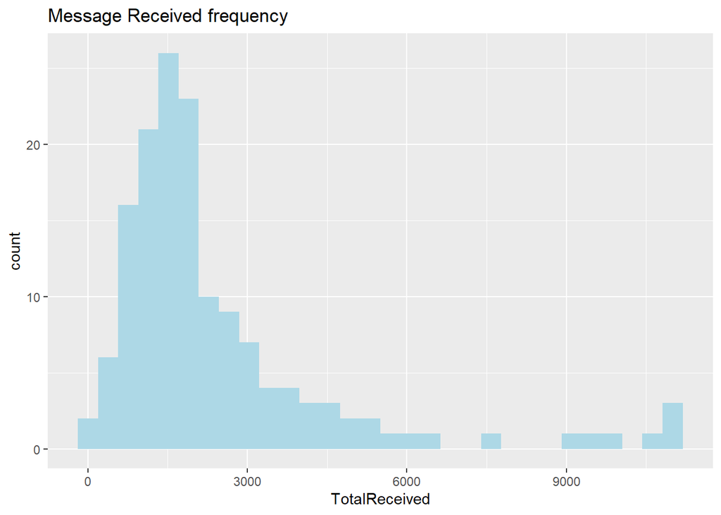

```r
# Plotting amount of message received by user in a histogramm
ggplot(data=MsgByUserRecipient)+
  geom_histogram(aes(x=TotalReceived),fill='lightblue')+
  ggtitle("Message Received frequency")
```

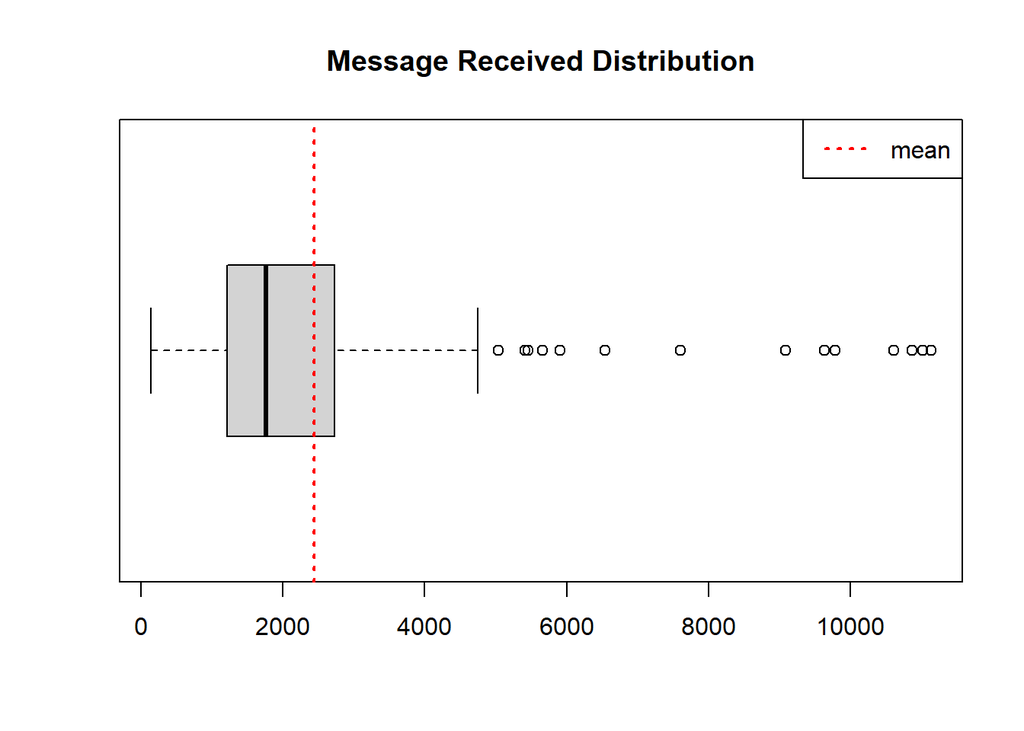

```r
# Understanding the distribution of amount of message received by user in a box plot
boxplot(MsgByUserRecipient$TotalReceived, horizontal = TRUE)
title("Message Received Distribution")
abline(v= round(mean(MsgByUserRecipient$TotalReceived),0), lty=3, lwd=2, col="red")
legend("topright", legend = c('mean'), lty = 3, lwd = 2, col = 'red')
```

```r
#Calculating the amount of message sent by an average user
MeanofMsgByUserRecipient <- round(mean(MsgByUserRecipient$TotalReceived),0)
print(paste("In average a user receives ", MeanofMsgByUserRecipient, "messages"))
```

```
## [1] "In average a user receives  2440 messages"
```

The box plot show us indeed a median close 1500 but because of the user receiving between 3000 and 12 000 emails, the mean averages 2500.

Indeed an average user received 2440 messages.

#### Is there messages that were broadly communicated or communicated to the entire organization ?

```r
#Table of the messages that were received by all the organization
ReceivedByAll <- UserRecipient %>% group_by(mid)%>% summarise(TotalUserRecipient = n()) %>% filter(TotalUserRecipient>=148)

#Messages that were the most received in the organisation
MidMostReceived <- UserRecipient %>%
  group_by(mid)%>%
  summarise(TotalUserRecipient = n()) %>%
  filter(TotalUserRecipient==max(TotalUserRecipient))

ReceivedByAll
```

```
## # A tibble: 0 × 2
## # ℹ 2 variables: mid <dbl>, TotalUserRecipient <int>
```

```r
MidMostReceived
```

```
## # A tibble: 31 × 2
##       mid TotalUserRecipient
##     <dbl>              <int>
##  1 252612                 67
##  2 255638                 67
##  3 257022                 67
##  4 257612                 67
##  5 258164                 67
##  6 267566                 67
##  7 269583                 67
##  8 270669                 67
##  9 271748                 67
## 10 272716                 67
## # ℹ 21 more rows
```

**COMMENT**  
0 messages was received by all user in the company. Indeed , no message appear to have be received by 148 person (149 user - 1sender).  
The maximum of recipient for a unique message was 67 and it was the case for 31 messages.

## (suite) OTHER QUESTIONS ADDRESSED RELATED TO OBJECTIVE 2:

**-Is there a status group that receives more emails than others?**  
**-Does the communication style varies according to status?**

```r
#Table of number of message received by user by rtype
MsgRtypeByUserStatus<- UserRecipient %>%
  group_by(status, rtype)%>%
  summarise(TotalReceived = n())
MsgRtypeByUserStatus
```

```
## # A tibble: 30 × 3
## # Groups:   status [10]
##    status          rtype TotalReceived
##    <fct>           <fct>         <int>
##  1 CEO             BCC             535
##  2 CEO             CC              535
##  3 CEO             TO             6050
##  4 Director        BCC            1740
##  5 Director        CC             1740
##  6 Director        TO            19002
##  7 Employee        BCC           17703
##  8 Employee        CC            17703
##  9 Employee        TO            66773
## 10 In House Lawyer BCC             186
## # ℹ 20 more rows
```

*!:It looks like all messges sent in CC was automatically sent in BCC or inversely*

Let’s analyze the proportion represented by each type of rtype for every status

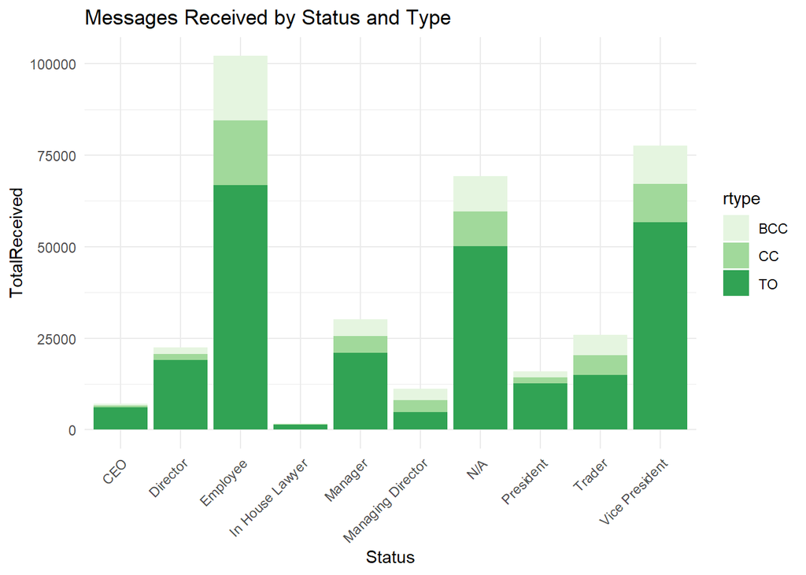

```r
ggplot(MsgRtypeByUserStatus, aes(x = status, y = TotalReceived, fill = rtype)) +
        geom_bar(stat = "identity") +
        labs(title = "Messages Received by Status and Type", x = "Status", y = "TotalReceived") +
        theme_minimal() +
        scale_fill_brewer(palette = "Greens")+ theme(axis.text.x = element_text(angle = 45, hjust = 1))
```

**COMMENT :** Employees were the one that received the most email. But all status received mostly messages directly address to them.  
However, we can notice that for the status that are C-level(President, CEO, Director), the indirect messages received represent a smaller portion of their total emails compared to other status.  
This make sens has people higher in organization hierarchy are less involved in the day to day activities and are usually solicitated only when really needed.

### What is the dynamic of messages received vs messages sent by status ?

```r
#Preparing the table that will be use to answer the question

#Number message sent by status (in value and percentage) - renaming the table for consistency
MsgSentByStatus <- MsgByStatus

#Number message rceived by status (in value and percentage)
MsgReceibedByStatus<- UserRecipient %>%
  filter(rtype!="BCC")%>%
  group_by(status)%>%
  summarise(TotalReceived = n())%>%
  mutate(TotalReceivedPercentage= round(TotalReceived/sum(TotalReceived)*100))

#Number user by status (in value and percentage)
EmployeeByStatus <- employeelistFN %>%
  group_by(status)%>%
  summarise(TotalUser = n())%>%
  mutate(TotalUserPercentage= round(TotalUser/sum(TotalUser)*100))


#Merge of the 3 tables below
StatusTable <-  MsgSentByStatus %>%
  inner_join(MsgReceibedByStatus, by = "status") %>%
  inner_join(EmployeeByStatus, by = "status")
head(StatusTable,2)
```

```
## # A tibble: 2 × 7
##   status   TotalSent TotalSentPercentage TotalReceived TotalReceivedPercentage
##   <fct>        <int>               <dbl>         <int>                   <dbl>
## 1 Employee     37267                  35         84476                      27
## 2 N/A          24313                  23         59686                      19
## # ℹ 2 more variables: TotalUser <int>, TotalUserPercentage <dbl>
```

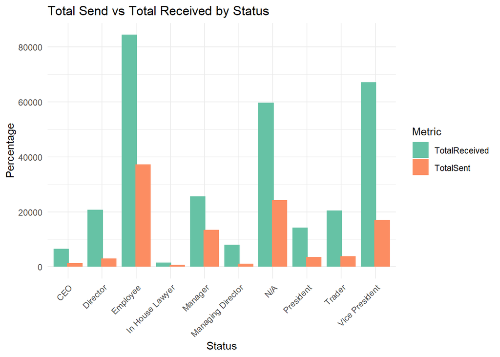

```r
# Reshape the data to long format
StatusTable_long2 <- StatusTable %>%
  pivot_longer(
    cols = c(TotalReceived, TotalSent),
    names_to = "Metric",
    values_to = "Percentage"
  )

# Create the grouped bar plot with dodged bars
ggplot(StatusTable_long2, aes(x = factor(status), y = Percentage, fill = Metric)) +
  geom_bar(stat = "identity", position = position_dodge(width = 0.8)) +
  labs(
    title = "Total Send vs Total Received by Status",
    x = "Status",
    y = "Percentage",
    fill = "Metric"
  ) +
  theme_minimal()+
  scale_fill_brewer(palette = "Set2")+ theme(axis.text.x = element_text(angle = 45, hjust = 1))
```

**COMMENT :**For all status there were more messages received than messages sent.  
But as certain status are more numerous than other it could be interesting to express the same data taking this information into account.

Considering that other status are more numerous than other, we decide to express all metrics as a percentage of the total.

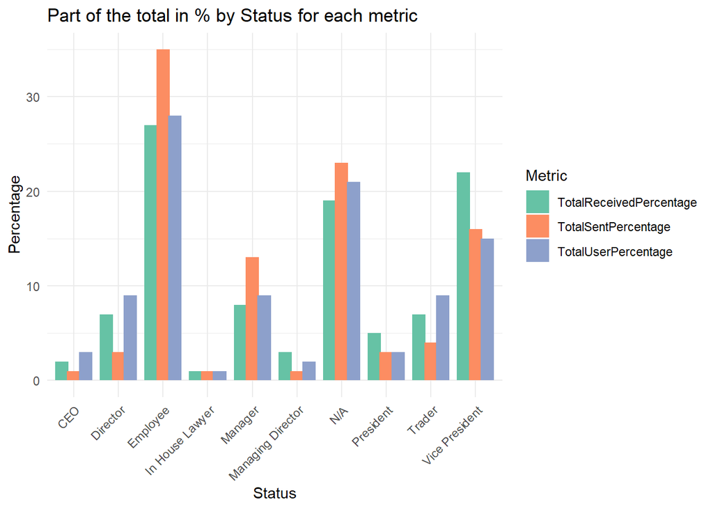

```r
# Reshape the data to long format
StatusTable_long <- StatusTable %>%
  pivot_longer(
    cols = c(TotalReceivedPercentage, TotalSentPercentage, TotalUserPercentage),
    names_to = "Metric",
    values_to = "Percentage"
  )

# Create the grouped bar plot with dodged bars
ggplot(StatusTable_long, aes(x = factor(status), y = Percentage, fill = Metric)) +
  geom_bar(stat = "identity", position = position_dodge(width = 0.8)) +  # Use position_dodge
  labs(
    title = "Part of the total in % by Status for each metric",
    x = "Status",
    y = "Percentage",
    fill = "Metric"
  ) +
  theme_minimal()+
  scale_fill_brewer(palette = "Set2")+ theme(axis.text.x = element_text(angle = 45, hjust = 1))
```

**COMMENT**: Put under the same scale, the latter plot seems to reinforce our precedent findings.  
Employees and N/A’s, status that might be more involved in day-to-day operation and common/group projects seems to exchange more.  
Vice President also have a high participation in exchanges but we observe that unlike the two precedent status, The Vice President received more emails than he sends. This could be explain by the more important CC aqnd BCC messages he has been receiving compared to the other upper class status.

For the trader status, the communication seems limited. They represent close to 9% of the user but only 4% of the messages sent and 7% of the messages received. This could be explain by the company organization, if each trader has his own stock portefolio to manage then few exchanges is needed.

# OBJECTIVE 3: ANALYZE ALL EMAILS DYNAMIC OVER TIME AND SENDER - RECIPIENT RELATION

### (general focus: user and non-user)

### RELEVANT INTERROGATIONS RELATED TO OBJECTIVE 3

**-What was the dates /the periods on which the most emails were exchange?**  
**-Use of specific email addresses or not overtime or during key periods**  
**-Message overtime between status A and status B_given the key date events**  
**-Message overtime between NON(user)/ (NON)user : do user received email outside of their main email address?, how many of the exchanges were between users?**

**-How many times did the user sent email outside out the organization? Who sends and received the most email to/from non user**  
**-How many time did the users received email coming from outside the organisation ?** **-Are email that goes out of the organization sent mostly from non primary email addresses?**

**GENERAL TABLE**

Building a general table including all recipient, all senders and all messages with their subject and content as previous dataset and tables were user-focused.

```r
#Building a general dataset by merging the 4 original data in the enron Rdata file

AllMessage_AllSender <- left_join(message,AllUser_wEmail, by = c("sender" = "Email"))

AllReceivers <- left_join(recipientinfo,AllUser_wEmail, by = c("rvalue" = "Email"))

AllMessage_AllSender_AllReceivers <- full_join(AllMessage_AllSender,AllReceivers, by = c("mid" = "mid")) %>% rename(eid_Emailer = eid.x, fullName_Emailer = fullName.x, status_Emailer = status.x, EmailIndex_Emailer =EmailIndex.x, eid_Recipient = eid.y,fullName_Recipient = fullName.y, status_Recipient = status.y, EmailIndex_Recipient =EmailIndex.y)

AllMessage_AllSender_AllReceivers_wContent <- full_join(AllMessage_AllSender_AllReceivers,referenceinfo, by = c("mid" = "mid")) %>% filter(year(date)>=1999 & year(date)<=2002)
```

Transforming the general table by adding column that could help with our analysis.

```r
#Adding a column to indicate if the sender/receiver was a user or not
#Adding a column to identify the user status involved in an exchange
#Adding a column to help group data by month date if needed

CompleteDataset <- AllMessage_AllSender_AllReceivers_wContent %>%
  mutate(ExchangeCat = case_when(
    is.na(eid_Emailer) & is.na(eid_Recipient) ~ "NON user - NON user",
    !is.na(eid_Emailer) & is.na(eid_Recipient) ~ "user - NON user",
    is.na(eid_Emailer) & !is.na(eid_Recipient) ~ "NON user - user",
    !is.na(eid_Emailer) & !is.na(eid_Recipient) ~ "user - user"
  ))%>%
   mutate(ExchangeStatus = paste(status_Emailer,status_Recipient,sep = "-"))%>%
   mutate(month_year = floor_date(date, "month"))
```

Column name of the complete dataset

```r
colnames(CompleteDataset)
```

```
##  [1] "mid"                  "sender"               "date"
##  [4] "message_id"           "subject"              "fullName_Emailer"
##  [7] "eid_Emailer"          "status_Emailer"       "EmailIndex_Emailer"
## [10] "rid"                  "rtype"                "rvalue"
## [13] "fullName_Recipient"   "eid_Recipient"        "status_Recipient"
## [16] "EmailIndex_Recipient" "rfid"                 "reference"
## [19] "ExchangeCat"          "ExchangeStatus"       "month_year"
```

### STUDYING TREND OF EMAIL OVER TIME

**Studying trend of email over time by mid**

```r
# Calculate the number of unique `mid` per date
trend_message <- CompleteDataset %>%
  group_by(date) %>%
  summarize(unique_mids = n_distinct(mid), .groups = 'drop')%>%  # Count unique `mid`
  arrange(desc(unique_mids))

# Calculate the number of unique `mid` per month-year
trend_message_byMD <- trend_message %>%
  mutate(month_year = floor_date(date, "month")) %>%
  group_by(month_year) %>%  # Group by month_year
  summarize(total_unique_mids = sum(unique_mids), .groups = 'drop')  %>%
  arrange(desc(total_unique_mids))
trend_message_byMD
```

```
## # A tibble: 46 × 2
##    month_year total_unique_mids
##    <date>                 <int>
##  1 2001-10-01             29556
##  2 2001-11-01             23441
##  3 2001-05-01             16986
##  4 2001-04-01             14348
##  5 2002-01-01             11948
##  6 2000-11-01             11388
##  7 2001-06-01             11128
##  8 2000-12-01             10899
##  9 2001-03-01             10686
## 10 2001-09-01              9888
## # ℹ 36 more rows
```

```r
# Plot the trend of unique message sent per date
trend_message_plot <- ggplot(data = trend_message_byMD, aes(x = month_year, y = total_unique_mids)) +
  geom_line(color = "blue", linewidth = 1) +
    labs(
    title = "Trend of Messent Sent Over Time",
    x = "Date",
    y = "Number of Unique MID"
  ) +
  theme_minimal() +
  theme(
    axis.text.x = element_text(angle = 45, hjust = 1)  # Rotate x-axis labels
  ,
    plot.margin = margin(t = 20, r = 20, b = 80, l = 20)  # Increase bottom margin
  )

girafe(code=print(trend_message_plot))
```

[interactive chart not shown]

**COMMENT :**

Based on two previous plots, the top periods when the most email were sent, are the following **periods of interest**:

**Oct-Nov 2001: around 54 000 msg -** ( coincide with the period of Enron announcing to investor that it was going to post 638 billions of lost and discloses a 1.2bn dollars reduction in shareholder equity - the emergence of the accounting fraud- Enron stock price going from 90 dollars to 12dollars per share )

**January 2002 around 12 000 msg -** : Andersen admits employees disposed of Enron documents. FBI investigation. 1 month after Enron filling for bankruptcy protection in Dec 2001.

**Studying trend of email over time by Email adress use to send the email**

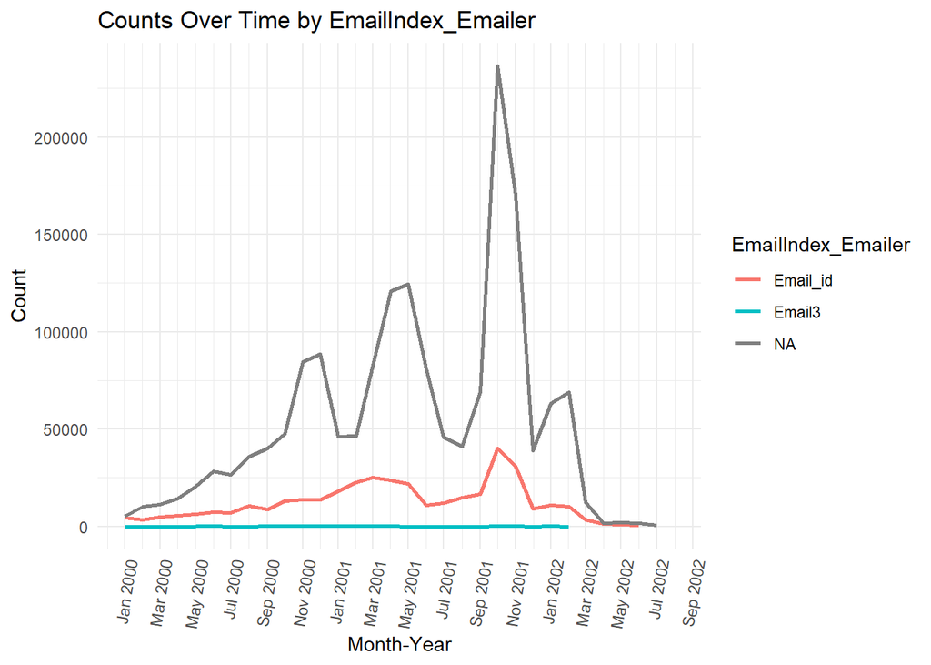

```r
# Create a  dataset summarizing by month_year and EmailIndex_Emailer
EmailIndex_Emailer_trend <- CompleteDataset %>%
  group_by(month_year, EmailIndex_Emailer) %>%
  summarize(count = n(), .groups = 'drop')

# Plot using the summarized data
ggplot(data = EmailIndex_Emailer_trend, aes(x = month_year, y = count, color = EmailIndex_Emailer, group = EmailIndex_Emailer)) +
  geom_line(size = 1) +  # Use lines to show trends
  scale_x_date(
    date_labels = "%b %Y",  # Format x-axis labels as "Month Year"
    date_breaks = "2 month", # Break x-axis by every month
    limits = c(as.Date("2000-01-01"), as.Date("2002-07-31"))  # Set date limits
  ) +
  labs(
    title = "Counts Over Time by EmailIndex_Emailer",
    x = "Month-Year",
    y = "Count",
    color = "EmailIndex_Emailer"
  ) +
  theme_minimal() +
  theme(
    axis.text.x = element_text(angle = 80, hjust = 1)  # Rotate x-axis labels for readability
  )
```

**COMMENT :**

Even though the emails sent from all EmailIndex tend to follow the same trend, during periods of interest ,messages sent by non registered email addresses (meaning non-users) seems to have surge compared to others

We still see a slight difference around January - February where registered email stay steady when non-registered email increase a bit

Note: this plot shows that user continue using their primary email address independently of the period.

**Studying trend of email over time between NON(user)/ (NON)user**

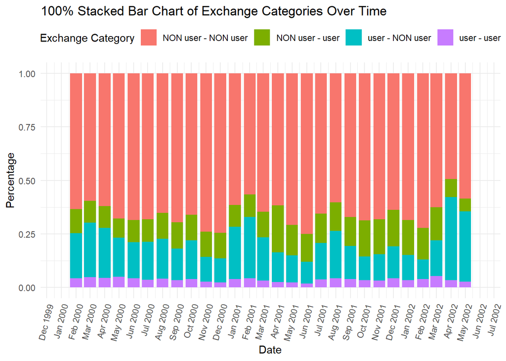

```r
ExchangeCat_trend <- CompleteDataset %>%
  group_by(month_year, ExchangeCat) %>%
  summarize(count = n(), .groups = 'drop') %>%
  mutate(percent = count / sum(count) * 100)  # Calculate percentages


# Plot using the transformed data
ggplot(data = ExchangeCat_trend, aes(x = month_year, y = percent, fill = ExchangeCat)) +
  geom_bar(stat = "identity", position = "fill") +  # 100% stacked bar chart
  scale_x_date(
    date_labels = "%b %Y",  # Format x-axis labels as "Month Year"
    date_breaks = "1 month",  # Break x-axis by every month
    limits = c(as.Date("2000-01-01"), as.Date("2002-05-31"))  # Set date limits
  ) +
  labs(
    title = "100% Stacked Bar Chart of Exchange Categories Over Time",
    x = "Date",
    y = "Percentage",
    fill = "Exchange Category"
  ) +
  theme_minimal() +
  theme(
    axis.text.x = element_text(angle = 75, hjust = 1),  # Rotate x-axis labels for readability
    legend.position = "top"  # Position legend at the top
  )
```

**COMMENT:**  
The NON-user to NON-user exchange is consistently the most exchange category represented.  
User to user exchanges seems to be stable  
Even almost imperceptible, we can also notice that during the period of interest April 2001, messages coming from outside the registered user being send to user gained proportion  
As far as user - non User exchanges are concerned, we can especially highlight their presence in April and May 2022. Possible event with link to “The DOJ indicts Arthur Andersen for obstruction of justice.”

In April 2002 and May 2002, the proportion of emails sent by user outside of the organization has almost double vs the previous month

### Which status interacted the most with non registered user ?

```r
StatusEmailingOut <- CompleteDataset %>%
  filter(ExchangeCat=="user - NON user" & EmailIndex_Emailer == "Email_id")%>%
  group_by (month_year,status_Emailer)%>%
  summarize(SentTo_NONuser= n(),.groups = "keep")
StatusEmailingOut
```

```
## # A tibble: 305 × 3
## # Groups:   month_year, status_Emailer [305]
##    month_year status_Emailer    SentTo_NONuser
##    <date>     <fct>                      <int>
##  1 1999-01-01 Employee                     111
##  2 1999-02-01 Employee                      41
##  3 1999-03-01 Employee                      53
##  4 1999-03-01 Vice President                 1
##  5 1999-04-01 Employee                      20
##  6 1999-05-01 Employee                     100
##  7 1999-05-01 Managing Director              7
##  8 1999-05-01 N/A                          304
##  9 1999-05-01 President                      9
## 10 1999-05-01 Vice President                15
## # ℹ 295 more rows
```

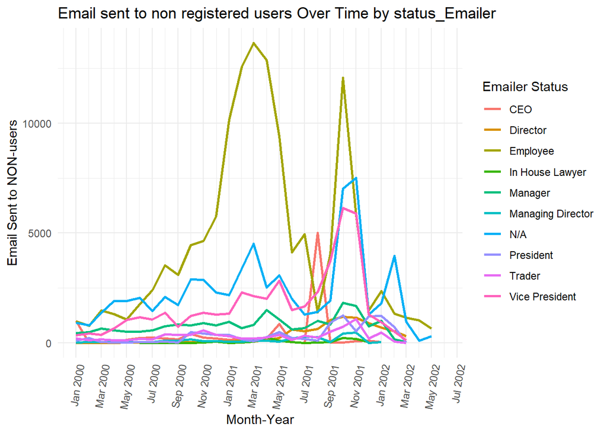

```r
# Plot using the summarized data
ggplot(data = StatusEmailingOut, aes(x = month_year, y = SentTo_NONuser, color = status_Emailer, group = status_Emailer)) +
  geom_line(size = 1) +  # Use lines to show trends
  scale_x_date(
    date_labels = "%b %Y",  # Format x-axis labels as "Month Year"
    date_breaks = "2 month", # Break x-axis by every month
    limits = c(as.Date("2000-01-01"), as.Date("2002-05-31"))  # Set date limits
  ) +
  labs(
    title = "Email sent to non registered users Over Time by status_Emailer",
    x = "Month-Year",
    y = "Email Sent to NON-users",
    color = "Emailer Status"
  ) +
  theme_minimal() +
  theme(
    axis.text.x = element_text(angle = 80, hjust = 1)  # Rotate x-axis labels for readability
  )
```

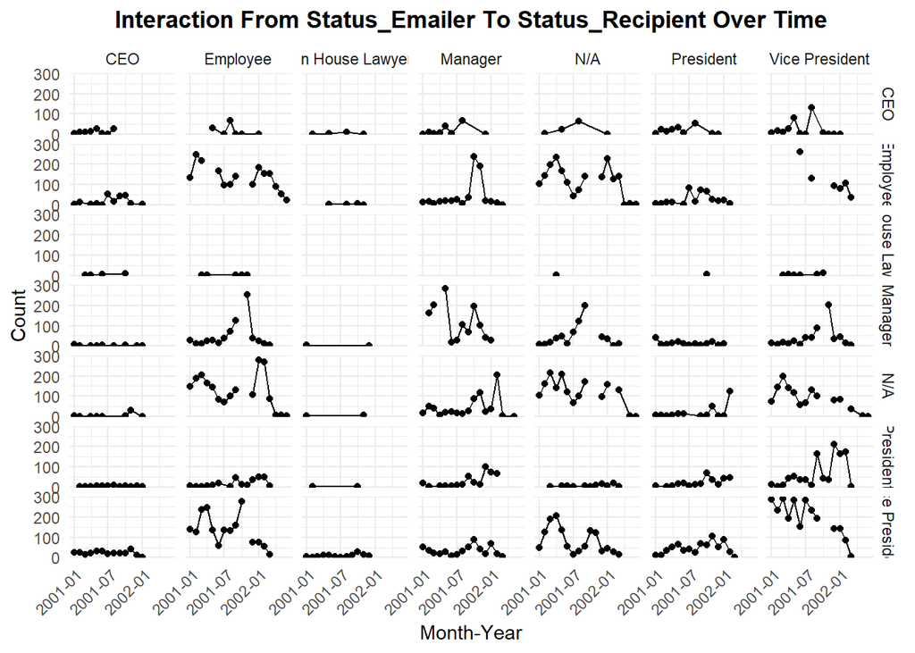

```r
StatusVSStatusData <- CompleteDataset %>%
  # Convert month_year to Date if it is not already
  mutate(month_year = as.Date(month_year, format = "%Y-%m-%d")) %>%  # Adjust the format as needed
  group_by(month_year, status_Emailer, status_Recipient) %>%
  filter(
    status_Emailer %in% c("President", "CEO", "Vice President", "In House Lawyer","N/A","Manager","Employee")  &
    status_Recipient %in% c("President", "CEO", "Vice President", "In House Lawyer", "N/A","Manager","Employee") &
    month_year >= as.Date("2001-01-01") &
    month_year <= as.Date("2002-06-30")
  ) %>%
  summarise(count = n(), .groups = 'keep')



ggplot(data=StatusVSStatusData)+
  geom_point(aes(x = month_year, y=count))+
  #geom_smooth(aes(x = month_year, y=count),method="lm")+
  geom_line(aes(x = month_year, y=count))+
  facet_grid(status_Emailer~status_Recipient)+
    scale_y_continuous(
    limits = c(0, 300),  # Set the y-axis limits from 0 to 300
    expand = c(0, 0)     # Prevent additional space beyond the limits
  ) +
  labs(
    title = "Interaction From Status_Emailer To Status_Recipient Over Time",
    x = "Month-Year",  # Label for x-axis
    y = "Count"        # Label for y-axis
  ) +
  theme_minimal() +
  theme(
    plot.title = element_text(hjust = 0.5, face = "bold"),# Center and bold the title
    axis.text.x = element_text(angle = 45, hjust = 1) # Rotate x-axis labels by 45 degrees

  )
```

# OBJECTIVE 4: ANALYZE EMAILS CONTENT

### QUESTIONS RELATED TO OBJECTIVE 4

**-Does the exchanges reflects that people were aware about the situation?**  
**-Were there any information shared about possible layoffs?**  
**-Content of Messages received or sent by Enron case person of interest if existent: Ken Lay (CEO), Jeff Skilling, Andrew Faston, Andersen Arthur**  
**-Content of message of “possible interaction of interest**

Adding information to the previous general dataset to help us answer our interrogation for objective 4 part.

```r
WordOfInterest <- "fraud|bankrupcy|layoffs|debt|lawsuit|litigation|resignation" # _Inserting to be research_

ContentCompleteDataset <- CompleteDataset %>%
  filter(!is.na(reference)) %>%
  mutate(
    word_exist = str_detect(tolower(reference), WordOfInterest), #binary column detecting the existence of the word
    word_count = str_count(tolower(reference), WordOfInterest), # counting how many times the terms appears
    word_extract = str_extract(tolower(reference), WordOfInterest) #extracting the first word found
  )


ContentCompleteDataset_TRUE <- ContentCompleteDataset %>%
  filter(word_exist == TRUE)
```

#### Estimating a time range for these topics

```r
#Estimating a time range for these topics
min(ContentCompleteDataset_TRUE$date)
```

```
## [1] "1999-09-23"
```

```r
min(ContentCompleteDataset_TRUE$date[ContentCompleteDataset_TRUE$word_count>1])
```

```
## [1] "2000-05-22"
```

```r
max(ContentCompleteDataset_TRUE$date)
```

```
## [1] "2002-06-18"
```

**COMMENT**: The topic first appear in the exchanges in Sept 1999. But it became more of a hot topic after May 2000. The topics were still mentioned in exchanges in June 2002.

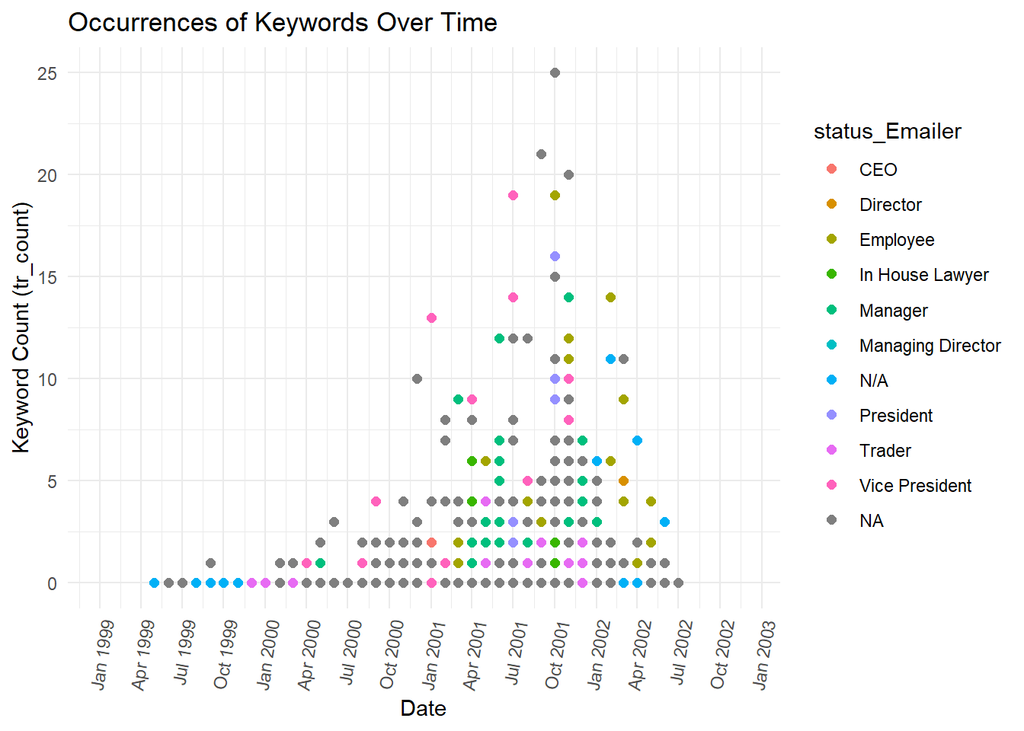

```r
ContentMessage <-CompleteDataset %>% distinct(mid,month_year,subject,reference,fullName_Emailer,status_Emailer,fullName_Recipient,status_Recipient) %>% mutate(word_count = str_count(tolower(reference), WordOfInterest))


ggplot(ContentMessage, aes(x = month_year, y = word_count, color= status_Emailer)) +
  geom_point(size = 2) +
  scale_x_date(
    date_labels = "%b %Y",  # Format x-axis labels as "Month Year"
    date_breaks = "3 month", # Break x-axis by every month
  ) +
  labs(
    title = "Occurrences of Keywords Over Time",
    x = "Date",
    y = "Keyword Count (tr_count)"
  ) +
  theme_minimal()+
  theme(
    axis.text.x = element_text(angle = 80, hjust = 1)  # Rotate x-axis labels for readability
  )
```

**COMMENT**: As expected the key words follows the trend of the period of interest and tension at Enron

### Determining the status and exchanges were the company’s situation was the most discuss.

```r
ContentCompleteDataset_TRUE %>%
  filter(word_count>=1) %>%
  group_by(ExchangeStatus)%>%
  summarize(NbExchange=n())%>%
  arrange(desc(NbExchange))
```

```
## # A tibble: 80 × 2
##    ExchangeStatus          NbExchange
##    <chr>                        <int>
##  1 NA-NA                         3773
##  2 Employee-NA                   1248
##  3 Vice President-NA              549
##  4 NA-Vice President              372
##  5 NA-Employee                    337
##  6 N/A-NA                         314
##  7 NA-N/A                         163
##  8 Manager-NA                     120
##  9 Employee-Vice President         99
## 10 NA-President                    93
## # ℹ 70 more rows
```

**COMMENT:** The topics were mostly at heart of the exchanges involving three status whether they were emailers or recipients :  
- NAs  
- Employees  
- Vice Presidents

#### Distribution of the words of interest in the conversations

```r
WordPieData <- ContentCompleteDataset_TRUE %>% group_by(word_extract) %>% summarise(WordExtractedCount = n()) %>%arrange(desc(WordExtractedCount))%>% mutate(WordExtractedCountPercentage= round(WordExtractedCount/sum(WordExtractedCount)*100))
WordPieData
```

```
## # A tibble: 7 × 3
##   word_extract WordExtractedCount WordExtractedCountPercentage
##   <chr>                     <int>                        <dbl>
## 1 debt                       3756                           47
## 2 litigation                 2301                           29
## 3 lawsuit                     915                           11
## 4 fraud                       405                            5
## 5 resignation                 378                            5
## 6 layoffs                     255                            3
## 7 bankrupcy                    26                            0
```

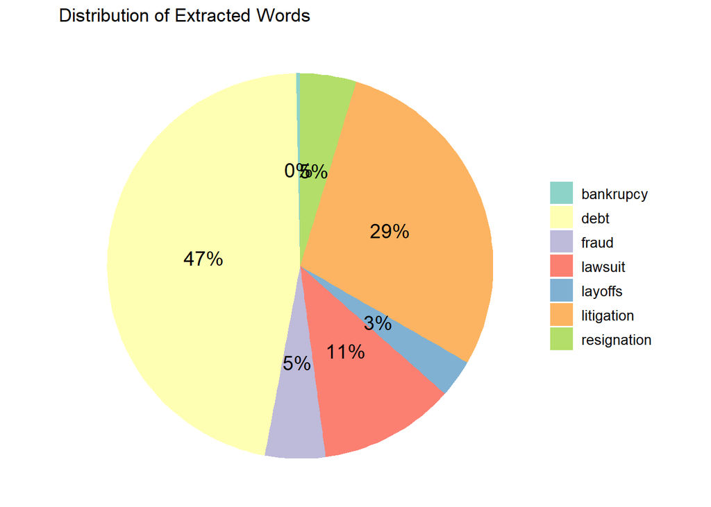

```r
# Pie representation of the distribution**
ggplot(data = WordPieData, aes(x = '', y = WordExtractedCount, fill = word_extract)) +
  geom_bar(stat = 'identity', width = 1) +  # Create bars to form a pie
  geom_text(aes(label = paste0(WordExtractedCountPercentage, '%')),
            position = position_stack(vjust = 0.5), color = 'black', size = 5) +  # Add percentage labels
  coord_polar(theta = 'y') +  # Turn the bar chart into a pie chart
  theme_void() +  # Remove background
  scale_fill_brewer(palette = "Set3") +  # Choose a color palette for better readability
  theme(legend.title = element_blank(),  # Remove legend title for clarity
        legend.text = element_text(size = 10))+  # Adjust legend text size
  ggtitle("Distribution of Extracted Words")
```

**COMMENT :** Most conversation are related to debt and litigation

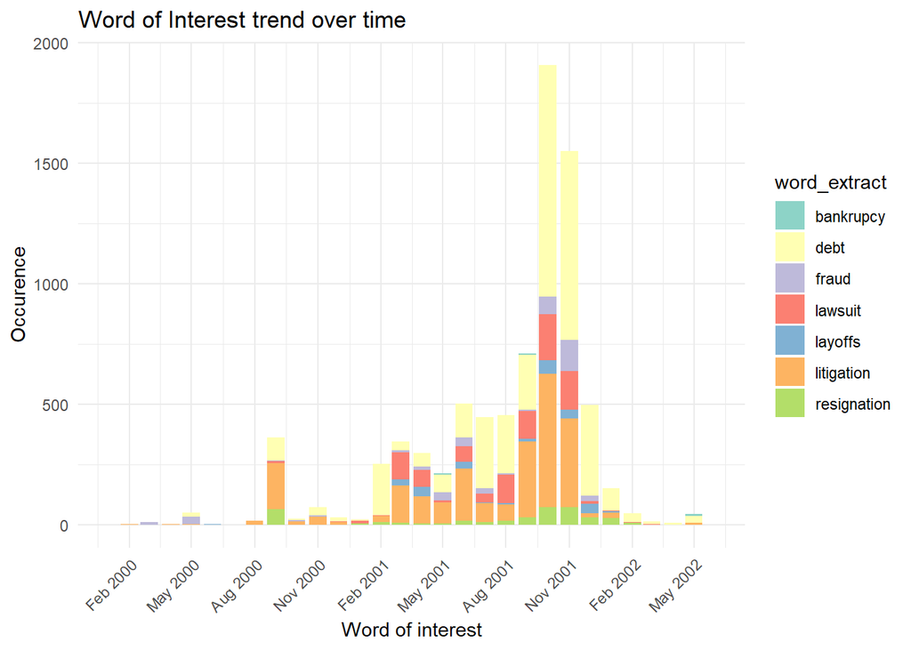

```r
WordLineTrendData <- ContentCompleteDataset_TRUE %>%
  select(month_year, word_extract) %>%
  group_by(month_year, word_extract) %>%
  mutate(WordExtractedCount = n()) %>%
  arrange(month_year) %>%
  distinct(month_year, word_extract, .keep_all = TRUE)

ggplot(WordLineTrendData, aes(x = month_year, y = WordExtractedCount, fill = word_extract)) +
        geom_bar(stat = "identity") +
    scale_x_date(
    date_labels = "%b %Y",  # Format x-axis labels as "Month Year"
    date_breaks = "3 month", # Break x-axis by every month
    limits = c(as.Date("2000-01-01"), as.Date("2002-05-31"))  # Set date limits
  ) +
        labs(title = "Word of Interest trend over time", x = "Word of interest", y = "Occurence") +
        theme_minimal() +
        scale_fill_brewer(palette = "Set3")+ theme(axis.text.x = element_text(angle = 45, hjust = 1))
```

**COMMENT:** During October 2001 and November 2001, period the most tense for the company, the topic off debts,fraud and lawsuit became predominant. We also observe a rise in resignations and layoff.  
*As a recall, in Oct-Nov 2001 :” Enron announcing to investor that it was going to post 638 billions of lost and discloses a 1.2bn dollars reduction in shareholder equity - the emergence of the accounting fraud- Enron stock price going from 90 dollars to 12dollars per share”*